[Coastal barometer website](http://folk.ntnu.no/erlenfau/KystBaro/) | [Coastal barometer blog](https://kystbarometeret.com) | [Ocean health index](http://www.oceanhealthindex.org) | [Citation policy](http://ohi-science.org/citation-policy/)

# Calculation of fisheries sustainability score

Marina Espinasse

2019-10-04

```r
library(stringr)
library(ggthemes)
library(scales)
library(zoo)
library(ggridges)
library(kableExtra)
```

# 1 Importing formatted catches and stocks data

```r
ices <- read.csv("data/ices_updated_2018.csv")
catch <- read.csv("data/fish_catch_by_municipality_update2018.csv")
seaarea <-read_excel(file.path(dir_M[2], "Fishery/DeliveryDataFiskDir/KommArea.xlsx"))
```

# 2 Merging catch data with ICES stocks data

```r
fish_nor <-catch %>%
           mutate(English = as.character(English)) %>%
           mutate(English = replace(English, English == "Atlantic cod", "Cod")) %>%
           mutate(English = replace(English, English == "Atlantic herring", "Herring")) %>%
           mutate(English = replace(English, English == "Red king crab", "Kingcrab")) %>%
           mutate(Spp_year = paste(English,Year, sep = "_")) %>%
           left_join(ices[,c(3,4,5,6,7)], by = "Spp_year") %>%
           rename("Species" = "English")
```

Checking the number of data points per species

```r
fish_nor %>% group_by(Species) %>%
             summarize(n = n())
```

```
## # A tibble: 6 x 2
##   Species      n
##   <chr>    <int>
## 1 Capelin    126
## 2 Cod       1622
## 3 Haddock   1530
## 4 Herring    440
## 5 Kingcrab   297
## 6 Saithe    1567
```

# 3 Further data cleaning: removing and re-arranging locations

Deleting municipalities that are not in the study (Beiarn county and Guovdageaidnu-Kautokeino) Re-estimating landings for the municipalities that were merged (Bodo + Skjerstad_2005, Bjarkoy_2013 + Harstad_2013) - I sum the landings for these pairs of municipalities for the years before they’ve merged.

```r
fish_nor_prep <- fish_nor %>%
                  mutate(Municip_name = as.character(Municip_name)) %>%
                  filter(!Municip_name %in% c("Beiarn", "Guovdageaidnu-Kautokeino")) %>% #mind the correct spelling of Guo... county
                  mutate(newid = case_when(Municip_name %in% c("Harstad_2013", "Bjarkoy_2013") ~ "1",
                                           Municip_name %in% c("Bodo", "Skjerstad_2005") ~ "2",
                                           TRUE ~ Municip_name)) %>%
                  group_by(newid, Year, Species) %>%
                  mutate(Total_catch_new = sum(Total_catch))
```

And now update the whole table, aggregate landings over counties that were merged, remove Skjerstad_2005 and Bjarkoy_2013. In this table, *Municip_name_new* are the names of the municipalities after they’ve merged. *Total_catch_new* is the total fish landings after municipalities merging.

```r
fish_nor_prep2<- fish_nor_prep %>%
                  select(-c("Municip_name", "Total_catch")) %>%
                  mutate(Municip_name_new = newid) %>%
                  mutate(Municip_name_new = replace(Municip_name_new, Municip_name_new == "1", "Harstad")) %>%
                  mutate(Municip_number = replace(Municip_number, Municip_name_new == "Harstad", "1903")) %>%
                  mutate(Municip_name_new = replace(Municip_name_new, Municip_name_new == "2", "Bodo")) %>%
                  mutate(Municip_number = replace(Municip_number, Municip_name_new == "Bodo", "1804")) %>%
                  ungroup() %>%
                  select(-newid) %>%
                  select(1,2,10,3:9)
```

# 4 Estimating sustainability score for each of the fish stocks

```r
fish_nor_estim <-fish_nor_prep2 %>%
                 mutate(Blim.Bmsy = Blim/Bmsy)

fish_nor_score <-fish_nor_estim %>% #estimating sustainability score for each stock (each species) - variable  "stock_score"
                 mutate(stock_score = case_when(
                                    SSB.Bmsy >= 1 ~ 1,
                                    SSB.Bmsy < 1 & SSB.Bmsy > Blim.Bmsy ~ (SSB.Bmsy - Blim.Bmsy)/Blim.Bmsy,
                                    SSB.Bmsy <= Blim.Bmsy ~ 0
                                    ))
```

# 5 Examining the distribution of total catch by species regardless of municipality

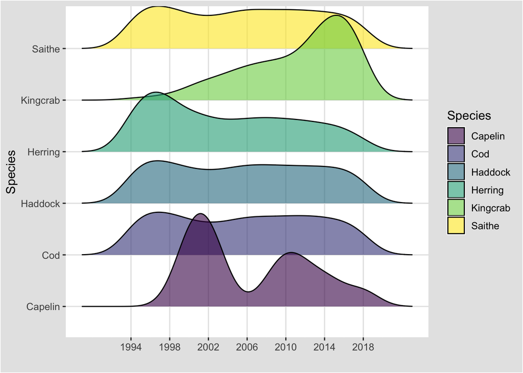

```r
catch_dist <- ggplot(data = fish_nor_score) +
  geom_density_ridges(aes(y = Species, x = Year, fill = Species)) +
  scale_x_continuous(breaks = seq(1994, 2018, 4)) +
  labs(x = "") +
  scale_fill_viridis_d(option = "D", alpha = 0.6) +
  theme_igray()
catch_dist
```

# 6 Estimating cacth per area and maximal weighted catch

(Check fisheries README. for details). This approach however, has a danger of positive outliers dominating the maximal catch per area. Due to multiple reasons, catch will vary in every municipality for each stock from year to year. Thus, a maximal catch (biomass) per area can be just an outlier, a seldomly seen very high catch. This is also seen in that most of the biomass.area/max.biomass.area ratios are very low (90% are less than 0.2).

```r
seaarea <- seaarea %>%
          mutate(Komnum = as.character(Komnum))

weighted_biomass_score <- fish_nor_score %>% #biomass per area weighted by maximal biomass per area
                        left_join(seaarea[,c("Havflate", "Komnum")], by = c("Municip_number" = "Komnum")) %>%
                         rename("Seaarea" = "Havflate") %>%
                         mutate(biomass.area = Total_catch_new/Seaarea) %>%
                         group_by(Species) %>%
                         mutate(max.biomass.area = max(biomass.area)) %>%
                         ungroup() %>%
                         mutate(weighted.biomass = biomass.area/max.biomass.area) %>%
                         mutate(weighted.biomass.sc = weighted.biomass*stock_score)

#Check the basic stats for weighted biomass score:
mosaic::fav_stats(weighted_biomass_score$biomass.area)
```

```
##          min     Q1 median   Q3  max mean   sd    n missing
##  0.000000578 0.0397  0.227 1.03 64.1 1.35 3.67 5563       0
```

```r
# min     Q1 median   Q3  max mean   sd    n missing
#  0.000000578 0.0397  0.227 1.03 64.1 1.35 3.67 5563  0
```

# 7 Re-estimate weighted catch per area based on smoothed catches

## 7.1 Apply 3-years rolling mean on catch data

Rolling mean is a remedy against inter-annual variability in catches and against influential outliers. I apply 3-year rolliing mean to catch data. However,rolling mean does not help to smooth variability in catches between the municipalities.

```r
municipalities <-unique(fish_nor_score$Municip_name_new)
species <-unique(fish_nor_score$Species)

splist <-list()
finallist <-list()
for (i in 1:length(municipalities))
  {
   mp <- municipalities[i]
   df.mp <- fish_nor_score %>%
      filter(Municip_name_new == mp)
    for (j in 1:length(species))
     {
        sp <- species[j]
        df.sp <- df.mp %>%
            filter(Species == sp)

      runmean <-data.frame(catch_runmean = rollapply(df.sp$Total_catch_new, width = 3, FUN = mean,  fill=NA))
      df.sp.full <- bind_cols(df.sp, runmean)
      splist[[j]] <- df.sp.full
      smoothed_catches_spp <- do.call("rbind", splist)
      finallist[[i]] <-smoothed_catches_spp

    }

 }

smoothed_catches <- do.call("rbind", finallist)
colSums(is.na(smoothed_catches))
```

```
##             Year   Municip_number Municip_name_new          Species
##                0                0                0                0
##         Spp_year              SSB             Bmsy         SSB.Bmsy
##                0              297              297                0
##             Blim  Total_catch_new        Blim.Bmsy      stock_score
##              297                0              297                0
##    catch_runmean
##              653
```

## 7.2 Re-esitmate weighted catch per area based on smoothed catches

```r
smoothed_weighted_biomass_score <- smoothed_catches %>%
                         left_join(seaarea[,c("Havflate", "Komnum")], by = c("Municip_number" = "Komnum")) %>%
                         rename("Seaarea" = "Havflate") %>%
                         filter(!is.na(catch_runmean)) %>%
                         mutate(biomass.area = catch_runmean/Seaarea) %>%
                         group_by(Species) %>%
                         mutate(max.biomass.area = max(biomass.area)) %>%
                         ungroup() %>%
                         mutate(weighted.biomass = biomass.area/max.biomass.area) %>%
                         mutate(weighted.biomass.sc = weighted.biomass*stock_score)
```

# 8 Check the distribution of biomass/area for each stock

## 8.1 Plot smoothed catches on a boxplot

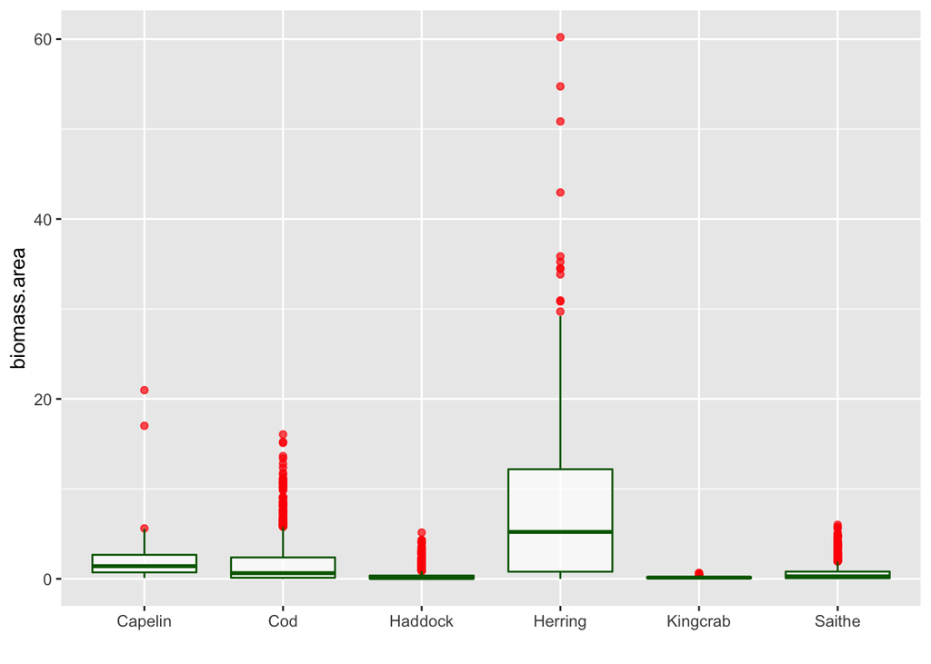

```r
plot2<- ggplot(smoothed_weighted_biomass_score) +
  geom_boxplot(aes(Species, biomass.area), color = "darkgreen", alpha = 0.7, fill = "transparent", outlier.color = "red") +
  labs(x = "")

#And a trucnated version
plot3<- ggplot(smoothed_weighted_biomass_score) +
  geom_boxplot(aes(Species, biomass.area), color = "darkgreen", alpha = 0.7, fill = "transparent", outlier.color = "red") +
  scale_y_continuous(limits = c(0,30))+
  labs(x = "")

plot2
```

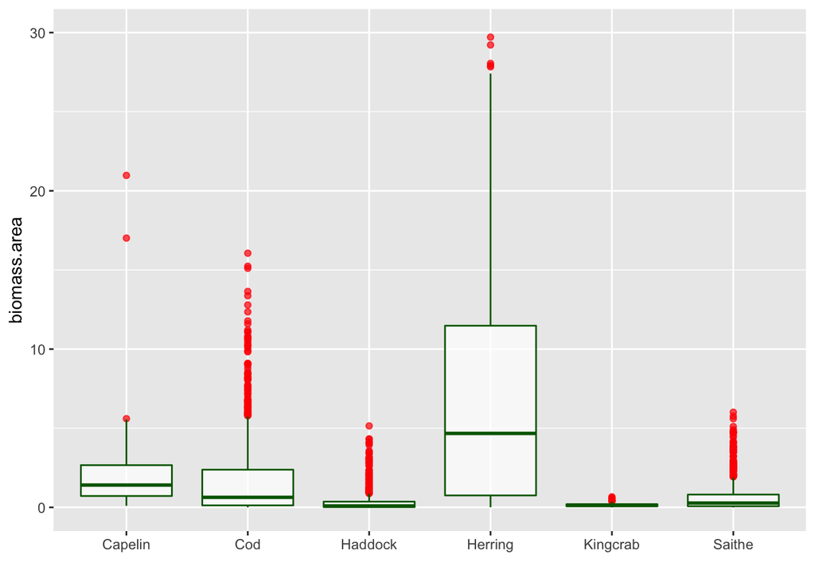

```r
plot3
```

## 8.2 Summarize smoothed catches in a table

```r
species <-unique(smoothed_weighted_biomass_score$Species)

outputdf <- list()
for (i in 1:length(species))
  {
   sp <- species[i]
   spdf <- filter(smoothed_weighted_biomass_score, Species == sp)
   stats <- mosaic::fav_stats(spdf$biomass.area)
   allstats <-cbind(stats, Species = rep(sp, 1))
   outputdf[[i]] <- allstats
}

biomass.area.favstats <- do.call("rbind", outputdf)

newtable <- biomass.area.favstats %>%
    mutate(Species = cell_spec(
    Species, color = "white", bold = T,
    background = spec_color(1:6, end = 0.9, option = "A", direction = -1))) %>%
    mutate(max = round(max, 2)) %>%
    mutate(max = cell_spec(
    as.numeric(max), "html",
    color = ifelse(max > 90, "red", "blue"))) %>%
    kable(escape = F, align = "c", digits = 4) %>%
    kable_styling(c("striped", "condensed"), full_width = F) %>%
    column_spec(1:10,bold = T,background = "azure", color = "darkgreen")
newtable
```

| min | Q1 | median | Q3 | max | mean | sd | n | missing | Species |
| --- | --- | --- | --- | --- | --- | --- | --- | --- | --- |
| 0.0001 | 0.1236 | 0.6323 | 2.379 | 16.06 | 1.603 | 2.214 | 1454 | 0 | Cod |
| 0.0070 | 0.7916 | 5.2121 | 12.187 | 60.21 | 8.117 | 9.450 | 340 | 0 | Herring |
| 0.0002 | 0.0205 | 0.0913 | 0.362 | 5.15 | 0.305 | 0.578 | 1369 | 0 | Haddock |
| 0.0000 | 0.0698 | 0.2725 | 0.807 | 6.01 | 0.593 | 0.829 | 1404 | 0 | Saithe |
| 0.0968 | 0.7184 | 1.4080 | 2.667 | 20.98 | 2.145 | 2.946 | 86 | 0 | Capelin |
| 0.0000 | 0.0689 | 0.1331 | 0.196 | 0.67 | 0.149 | 0.111 | 257 | 0 | Kingcrab |

# 9 Calculate final fisheries scores based on smoothed weighted catches per area

```r
final_scores_smoothed_area <- smoothed_weighted_biomass_score %>%
                  group_by(Year, Municip_number, Municip_name_new) %>%
                  mutate(total_tons = sum(catch_runmean)) %>%
                  mutate(catch_prop = catch_runmean/total_tons) %>%
                  summarize(fish_score = sum(weighted.biomass.sc*catch_prop*100))

#write_csv(final_scores_smoothed_area, "data/fishery_final_score_smoothed_by_area.csv")
```

# 10 Quick-check of the distribution of area-weighted final score

```r
mosaic::fav_stats(final_scores_smoothed_area$fish_score)
```

```
##       min   Q1 median   Q3  max mean   sd    n missing
##  0.000738 1.48   7.48 18.2 99.9 12.5 14.9 1465       0
```

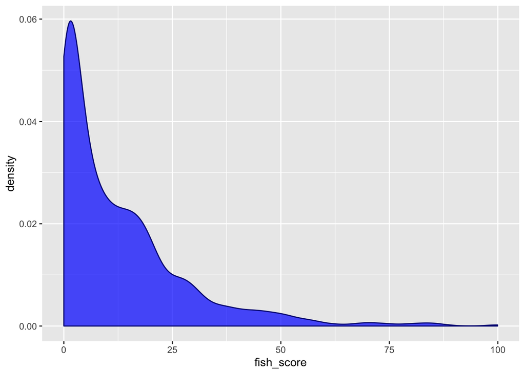

```r
plot<- ggplot(final_scores_smoothed_area) +
        geom_density(aes(fish_score), fill = "blue", color = "navy", alpha = 0.7)
plot
```

# 11 Using 0.75th quartile of catch per area as a target

```r
smoothed_weighted_biomass_score_quantile <- smoothed_catches %>%
                         left_join(seaarea[,c("Havflate", "Komnum")], by = c("Municip_number" = "Komnum")) %>%
                         rename("Seaarea" = "Havflate") %>%
                         filter(!is.na(catch_runmean)) %>%
                         mutate(biomass.area = catch_runmean/Seaarea) %>%
                         group_by(Species) %>%
                         mutate(biomass.area.q75 =quantile(biomass.area, probs = 0.75)) %>%
                         ungroup() %>%
                         mutate(weighted.biomass = ifelse(
                           biomass.area > biomass.area.q75, 1, biomass.area/biomass.area.q75)) %>%
                         mutate(weighted.biomass.sc = weighted.biomass*stock_score)
```

# 12 Recalcualte fisheries score based on 0.75th quartile of catch as a reference

```r
final_scores_smoothed_area_q75 <- smoothed_weighted_biomass_score_quantile %>%
                  group_by(Year, Municip_number, Municip_name_new) %>%
                  mutate(total_tons = sum(catch_runmean)) %>%
                  mutate(catch_prop = catch_runmean/total_tons) %>%
                  summarize(fish_score = sum(weighted.biomass.sc*catch_prop*100))

write.csv(final_scores_smoothed_area_q75, "data/fish_score_smoothed_seaarea.csv")
```

# 13 Quick-check of the distribution of area-weighted final score based on 0.75th qunatile

```r
mosaic::fav_stats(final_scores_smoothed_area_q75$fish_score)
```

```
##      min   Q1 median   Q3 max mean   sd    n missing
##  0.00498 11.4   47.9 88.8 100 49.2 37.3 1465       0
```

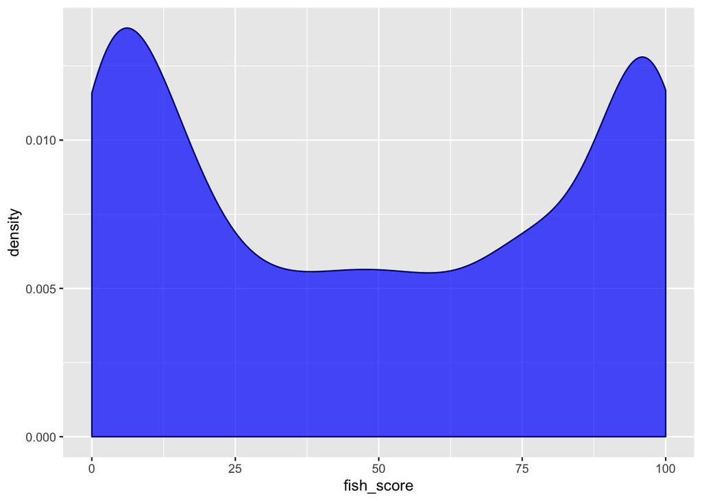

```r
plot4<- ggplot(final_scores_smoothed_area_q75) +
        geom_density(aes(fish_score), fill = "blue", color = "navy", alpha = 0.7)
plot4
```